# MOD 3

NHUNG NGUYEN

2023-11-21

```r
DATA = merge(Clinicaldatawoo , SVI_noID, by.x = "pseudocounty", by.y =  "pseudoSTCNTY")
```

```r
Selected_DATA <- DATA %>% select(psychipr,rel,trm,intxsurv)

head(Selected_DATA, 4)
```

```
##   psychipr rel trm intxsurv
## 1        0   0   1    2.138
## 2        0   1   0   74.704
## 3        0   0   0   86.711
## 4        0   0   0   12.796
```

```r
DATA = Selected_DATA %>%
  filter(intxsurv < 5000)%>%
  mutate(intxsurv = as.numeric(intxsurv),
         trm= ifelse(trm == 1 , "Death", "No Death"),
         trm = as.factor(trm),
         rel = ifelse(rel == 1 , "Has Relapse", "No Relapse"),
         rel = as.factor(rel),
         psychipr = ifelse(psychipr == 1 , "Has Psychiatric Assistance", "No Psychiatric Assistance"),
         psychipr = as.factor(psychipr))
```

```r
set.seed(1)
data_split <- initial_split(DATA, prop = 0.75)
train_data <- training(data_split)
test_data <- testing(data_split)
```

```r
tree_spec <- decision_tree() %>%
 set_engine("rpart") %>%
 set_mode("classification")
```

```r
tree_fit <- tree_spec %>%
 fit(trm ~ intxsurv + rel + psychipr, data = train_data)
```

```r
predictions <- tree_fit %>%
 predict(test_data) %>%
 pull(.pred_class)
```

```r
library(yardstick)
metrics <- metric_set(accuracy)
model_performance <- test_data %>%
 mutate(predictions = predictions) %>%
 metrics(truth = trm, estimate = predictions)

print(model_performance)
```

```
## # A tibble: 1 × 3
##   .metric  .estimator .estimate
##   <chr>    <chr>          <dbl>
## 1 accuracy binary         0.938
```

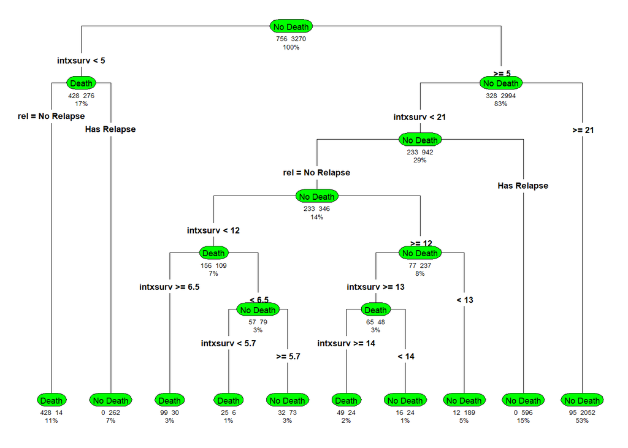

```r
par(cex = 0.7)

a = rpart.plot(tree_fit$fit, type = 4, extra = 101, under = TRUE, cex = 0.8, box.palette = "green")
```

**a. Discuss the model accuracy** -> The model accuracy is 0.93, which is a pretty high accuracy for a classification tree

**b. Make 1 prediction for 2 new observations. Their outcomes should be from different groups.**

```r
new_data <- tribble(
  ~intxsurv, ~rel, ~psychipr,
  7.9, "No Relapse", "Has Psychiatric Assistance"
)

prediction <- predict(tree_fit, new_data)
print(prediction)
```

```
## # A tibble: 1 × 1
##   .pred_class
##   <fct>
## 1 Death
```

```r
new_data <- tribble(
  ~intxsurv, ~rel, ~psychipr,
  500, "Has Relapse", "Has Psychiatric Assistance"
)

prediction <- predict(tree_fit, new_data)
print(prediction)
```

```
## # A tibble: 1 × 1
##   .pred_class
##   <fct>
## 1 No Death
```

**c. Interpret the Decision Tree**

Below are the observations that have different criteria based on their Relapse and Survival Rate.

1. If the interval between transplant and survival date is lower than 5 and there is no Relapse, there is likely to be death due to treatment. But if there is Relapse, there is likely to be no death due to treatment
2. If the interval between transplant and survival date is lower than 21 and there is Has Relapse there is likely to be no death due to treatment
3. If the interval between transplant and survival date is lower than 21 and there is no Relapse, there are 2 subsets of outcomes that could happen :

I. Intxsurv < 12 a. If interval between transplant and survival date is lower than 12 and higher than 6.5, there is likely to be death due to treatment

2. If interval between transplant and survival date is lower than 12 and lower than 5.7, there is likely to be death due to treatment, but if it is lower than 12 and higher than 5.7, there is likely to be no death due to treatment
1. If interval between transplant and survival date is higher than 14 , there is likely to be death due to treatment
2. If interval between transplant and survival date is lower than 14 , there is likely to be no death due to treatment

**d. What was the most important variable based on the variable importance plot?** -> The most important variable based on the variable importance plot is intxsurv.

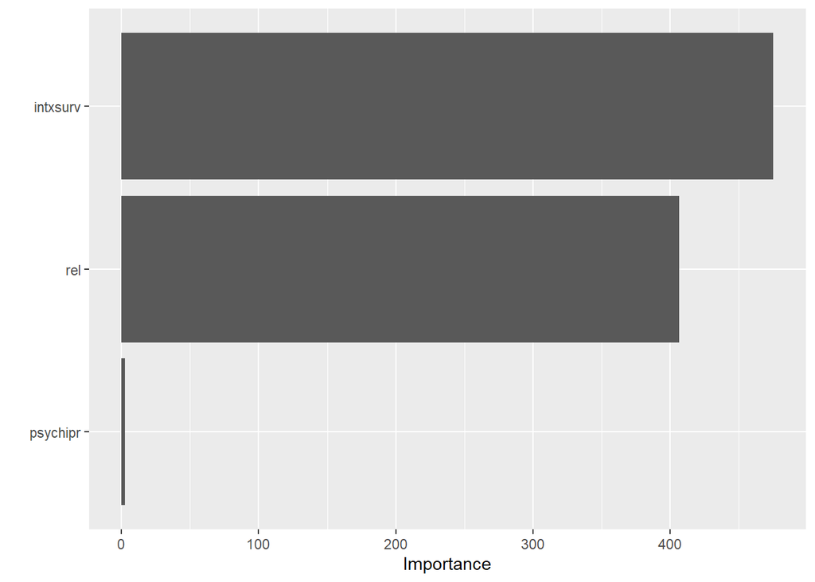

```r
var_importance <- vip::vip(tree_fit, num_features = 10)
print(var_importance)
```